# Stratification of breast cancer by PAM50 subtypes: Clinical and molecular characterisation in the METABRIC Cohort

# Abstract

**Background:** As reported by WHO, breast cancer remains a significant healthcare challenge with more than half a million deaths in 2022. Traditional classification based on tumour stage and receptor status is not sufficient to tackle this heterogeneous disease. Ultimescu et al. (2024) mention the growing evidence of molecular profiling significance in management and treatment of breast cancer. This study evaluates whether a gene-expression classifier Prediction Analysis of Microarray 50 (PAM50) meaningfully stratifies clinical characteristics, mutational variations and transcriptional variation within the METABRIC cohort.

**Methods:** METABRIC dataset has been used to integrate clinical metadata, normalized gene expression matrices and somatic mutation data. Principal component analysis (PCA) has been conducted to evaluate overall transcriptomic structure. Differential expression of selected genes was assessed using Wilcoxon rank-sum tests. Somatic mutations patterns and tumour mutation burden (TMB) were analyzed using *Maftools* package, and mutation profiles were compared across PAM50 subtypes.

**Conclusions:** PAM50 subtypes reflect biologically meaningful but overlapping mutational and transcriptional patterns. While molecular subtypes (such as Luminal A and HER2) support our ability to better classify breast cancers, malignant tumors do not form distinct isolated groups and share some of the biological characteristics on the classification boundaries of subtype gene expression.

**Keywords:** Breast cancer, METABRIC, PAM50, Luminal A, HER2, molecular subtyping, gene expression, mutations

# Introduction

Despite significant progress in cancer care made in recent years, as well as in our general understanding of the nature of the disease, comprehensive Kim et al. (2025) research on breast cancer incidence and mortality trends in 185 countries concludes that the number of incidences will continue to increase. With the recent advancements in digital and computational pathology, genomic sequencing and liquid biopsy technologies, as well as other related fields including machine learning and AI-assisted image recognition, our ability to go beyond traditional classification methods of cancer has dramatically improved.

Rakha et al. (2022) provide a comprehensive historic overview over the pathological classification of breast cancer, which relied on tumour size, lymph node involvement, histological grade and receptor status. As cancer researchers, oncologists and anyone working in the field of oncology knows, the heterogeneous nature of this disease could not be fully understood without identifying relevant biological and molecular features.

Improvements in transcriptomic profiling technologies have enabled the development of molecular classification tools such as PAM50 subtype classifier (Parker et al., 2009), which categories tumors into specific subtypes (Luminal A, Luminal B, HER2 enriched and Basal-like) based on the expression of 50 genes. These subtypes revealed important insights about the differences in tumor biology reflecting proliferation activity, tumor differentiation, as well as pathway activation patterns. Most importantly, this molecular classification added significant predictive and prognostic value when compared to the clinical and pathological model or subtype modelling alone. Such multimodal approaches combining clinical and molecular characteristics have been increasingly adopted by Multi-Disciplinary teams (MDTs) to improve patient outcomes.

The Molecular Taxonomy of Breast Cancer International Consortium (METABRIC) dataset provides well-structured breast cancer cohort data with matched clinical, genomic and transcriptomic characteristics. The availability of mutation annotation files (MAF) and normalized gene expression data makes this dataset particularity useful for evaluating practical relevance of molecular subtyping and biological coherence.

The primary objective of this research is to determine whether PAM50 subtypes could meaningfully stratify transcriptional variation, subtype-specific mutation patterns, as well as clinical characteristics within the METABRIC cohort. More specifically, the study examines transcriptomic structure using principal component analysis, compares differential expression of selected genes, analyzes mutation patterns and tumour mutation burden, as well as evaluates concordance between clinical characteristics and intrinsic molecular subtypes.

# Results

## Cohort Characteristics

**Table 1. Cohort characteristics by PAM50 subtype (Luminal A and HER2-enriched)**

| Characteristic | Her2 | LumA |
| --- | --- | --- |
| Number of patients | 224.0 | 700.0 |
| Mean age | 58.8 | 62.9 |
| ER positive (%) | 47.2 | 98.1 |
| HER2 gain (%) | 66.5 | 11.0 |

Table 1 presents a summary of basic demographic and clinical characteristics of patient cohort stratified by PAM50 subtype (Luminal A and HER2-enriched). Mean age at diagnosis was not dramatically different across subtypes, although Luminal A was associated with a slightly higher age. As far as the biological differences are concerned, HER2-enriched tumors reflected higher rates of HER2 amplification, while Luminal A tumors were predominantly ER-positive.

## Gene Expression Analysis Across Two Breast Cancer PAM50 Subtypes

In order to investigate how gene expression differs between breast cancer subtypes in the METABRIC cohort, we integrated transcriptomic data with clinical subtype annotations. Expression-based PAM50 subtypes were selected as the primary stratification variable, as they are widely used in breast cancer research and capture biologically meaningful differences related to hormone receptor signaling, proliferation, and tumor aggressiveness.More specifically, Luminal A and HER2-enriched were chosen for focused comparison, given their inherently distinct biological mechanisms and significant role they play in optimizing cancer treatment strategies. Gao and Swain (2018) demonstrated that accurate identification of Luminal A breast cancer provides a subset of cancer patients with the opportunity to forego chemotherapy, since endocrine therapy alone might be sufficient. This has very important practical implication on the patient’s quality of life as they could avoid unnecessary toxicity associated with this intensive form of treatment. HER2 remains a definitive biomarker for targeted breast cancer therapies and has a significant prognostic value in cancer management (Zhou et al., 2025).

Clinical metadata and gene expression data were first loaded and inspected to confirm their structure and consistency. The expression matrix consisted of gene-level measurements with samples represented as columns and genes identified by Hugo gene symbols.

Because some genes appeared multiple times in the expression matrix (likely due to multiple probes mapping to the same gene), duplicate gene entries were resolved by aggregating rows with the same Hugo Symbol and computing the mean expression value across duplicates. This produced a single expression profile per gene and ensured compatibility with downstream multivariate analyses. Given that expression values were already scaled and centered, averaging across duplicates was considered appropriate and did not distort relative expression patterns.

To ensure consistent integration, only samples present in both the clinical metadata and expression matrix were retained. The expression matrix was then converted into a numeric matrix with genes as rows and samples as columns. Principal component analysis (PCA) was performed using the prcomp() function after transposing the matrix, as PCA requires samples as rows and features as columns. Although the expression data appeared pre-scaled (containing both positive and negative values), scaling was retained within prcomp() to ensure each gene contributed equally to the variance structure.

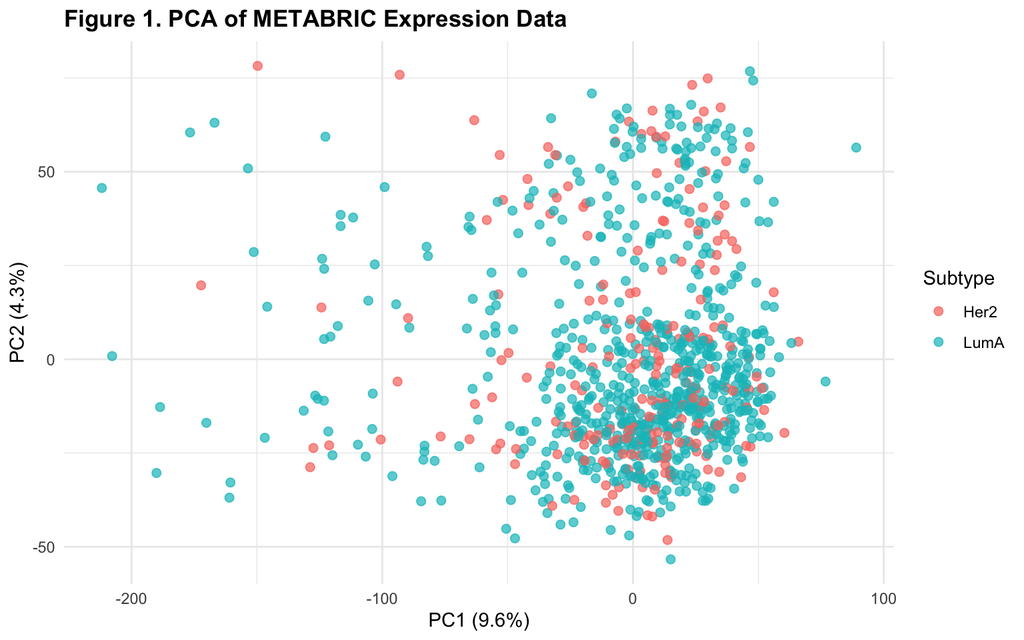

Figure 1 demonstrates how tumor samples cluster according to variation in gene expression. When the top 2 PCs were visualized and colored by PAM50 subtype, Luminal A tumor and HER2 subtypes surprisingly clustered together, with minimal separation between the two. This suggests that the top 2 PCs are not dominantly influenced by the genes that would separate Luminal A and HER2 subtypes, and that it those genes are likely influencing other PCs.

**Table 2. Top 10 genes contributing to PC1**

| Gene | Loading |
| --- | --- |
| KRTAP3-2 | 0.0228 |
| PLGLA | 0.0228 |
| LINC01122 | 0.0224 |
| MTHFR | 0.0223 |
| OR8J1 | 0.0221 |
| NAV3 | 0.0220 |
| BEX2 | 0.0218 |
| PRKACA | 0.0217 |
| NFE2 | 0.0217 |
| SGCB | 0.0216 |

Table 2 depicts the top 10 genes contributing mostly to the first principal component (PC1), which represents the dominant axis of transcriptional variation, were not necessarily classical subtype-defining markers. This suggests that the main pattern of variation reflects general tumor heterogeneity rather than specific molecular subtype differences.

To identify important genes and biological processes that might reveal variation between the Luminal A and HER2 subtypes, particular genes of interest (ESR1, ERBB2, MKI67, KRT5, and KRT14) were visualized in boxplots comparing Luminal A and HER2 subtypes.

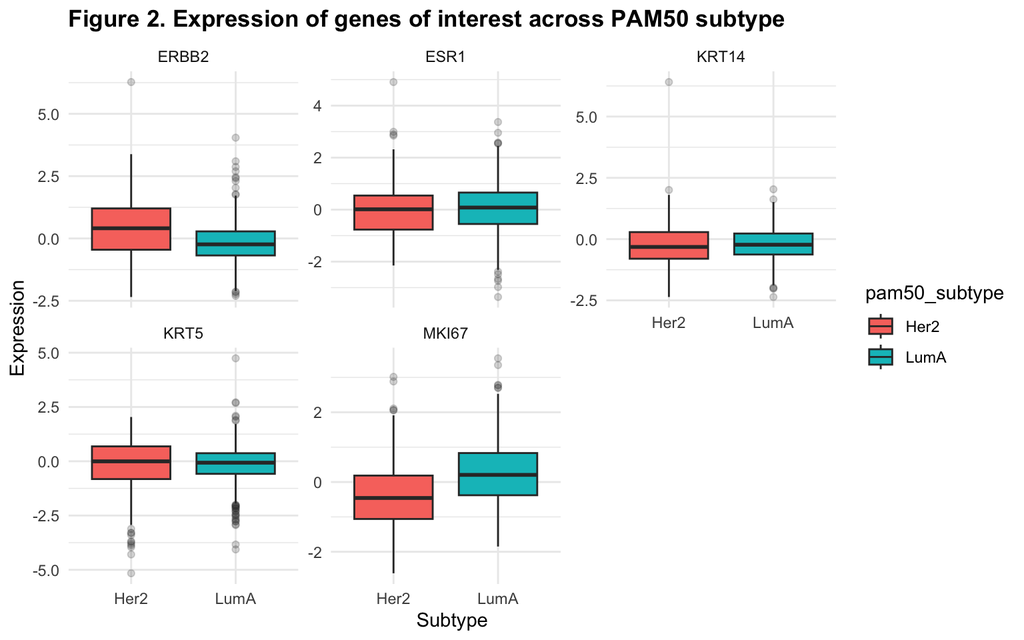

Figure 2 illustrates that ERBB2 and MKI67 in particular appear to have differential expression, with ERBB2 being higher in the HER2 subtype. This is expected, given that the HER2 subtype is defined by higher relative expression of ERBB2 and has been consistently demonstrated in the previous studies (Prat et al., 2013). However, MKI67 appeared higher in the Luminal A subtype, which contradicts previously published literature (Soliman and Yussif, 2016) that suggests that the HER2 subtype tends to have higher MKI67 expression. This might be caused by the cohort-specific differences between studies.

## Mutation Patterns and Cancer Driver Genes

To characterize somatic mutation patterns in the METABRIC cohort, mutation data in Mutation Annotation Format (MAF) were analyzed using the maftools package. Clinical subtype annotations were explicitly linked to mutation data via unique patient identifiers present in both the metadata and mutation data. The total mutation burden across samples was calculated by dividing the total number of mutations in a sample by its number of megabases and the results were visualized with a histogram. An oncoplot was generated to visualize the most frequently mutated genes in the cohort.

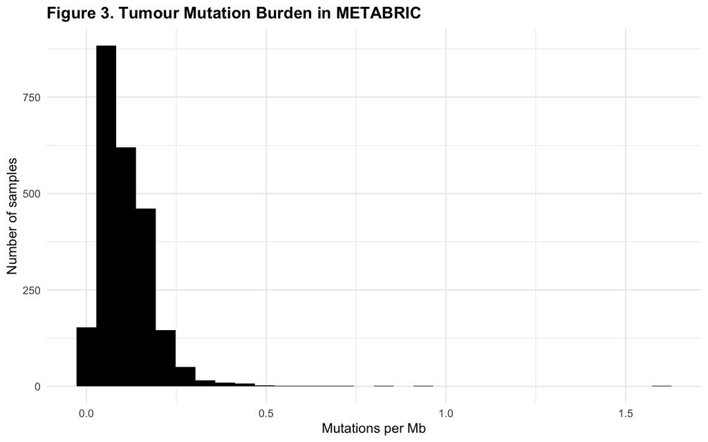

Figure 3 shows right-skewed distribution that showed most tumors in this dataset have a similar number of mutations per megabase, with a few outliers with a higher number of mutations per megabase.

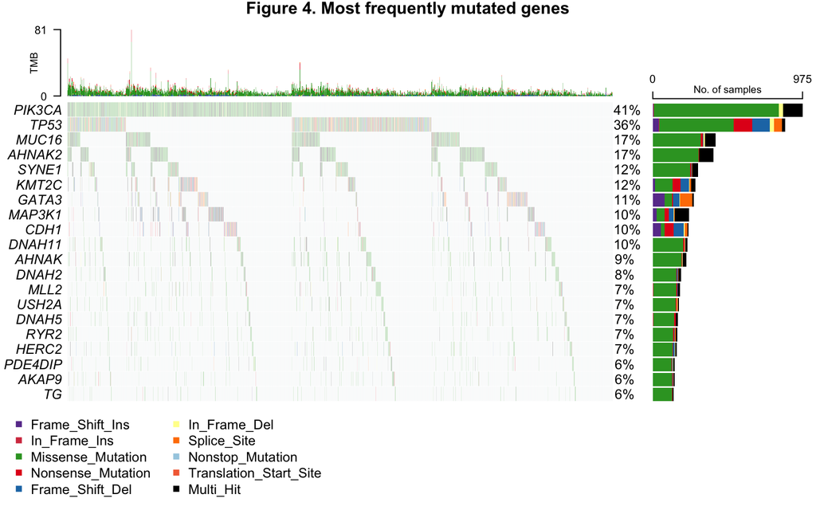

Figure 4 displays genes as rows and samples as columns, with mutation types encoded by color, and genes ordered by the percentage of samples they are mutated in. It revealed that PIK3CA and TP53 were the most frequently mutated genes overall. These results are consistent with the findings of the report published by The Cancer Genome Atlas Network (2012), which indicated that both PIK3CA and TP53 are among the most frequently mutated genes in breast cancer.

To identify patterns of mutations in subtypes, the columns in the oncoplot were then sorted by PAM50 subtype, allowing subtype-specific mutation patterns to be readily identified.

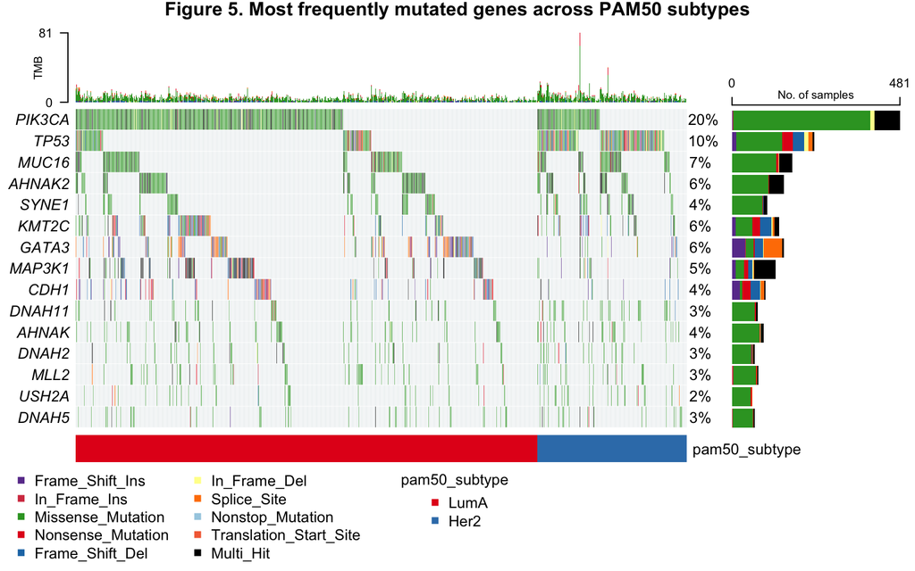

Figure 5 demonstrates that while a roughly similar proportion of Luminal A and HER2 samples had PIK3CA mutations, a much larger proportion of HER2 samples had TP53 mutations. Conversely, Luminal A samples had a higher proportion of KMT2C, GATA3, and MAP3K1 mutations. These findings indicate that specific driver genes are more common in particular PAM50 subtypes.

## Integration of Molecular Features with Clinical Characteristics

To explore how molecular features relate to clinical characteristics, gene expression, mutation burden, and driver gene mutations were integrated with clinical variables including estrogen receptor (ER) status and HER2 mutation-type.

PCA results from the expression analysis were further annotated with clinical variables such as ER status and HER2 status.

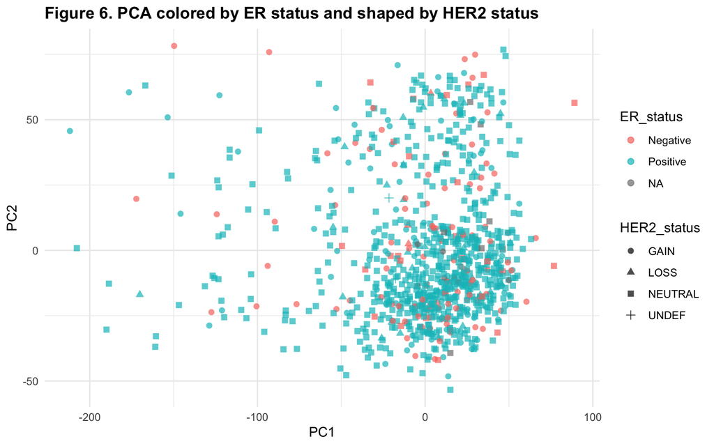

Figure 6 indicates that very few HER2 loss mutations resulted in negative ER status, with a majority of negative ER status patients exhibiting HER2 gain or neutral mutations.

TMB values were merged into the clinical dataset, enabling comparison across PAM50 subtypes and clinical groups.

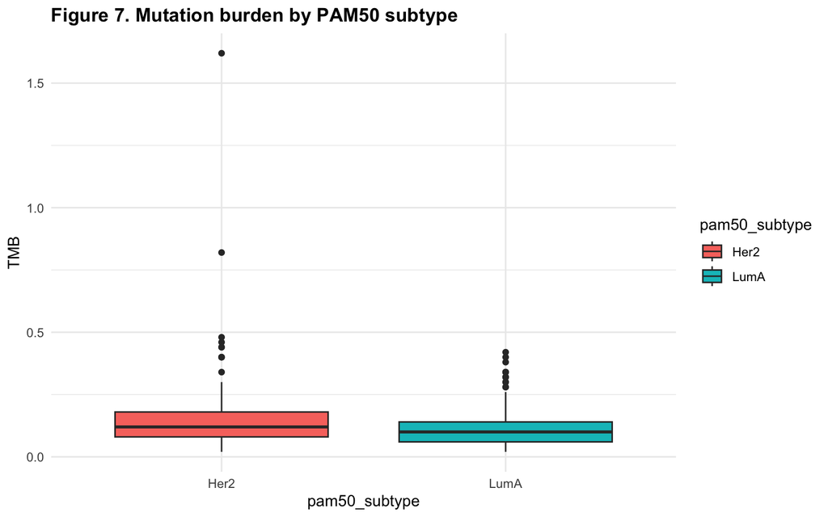

Figure 7 demonstrates that HER2 tumors generally exhibited slightly higher mutation burden with a few samples with a notably higher number of mutations per megabase. However, substantial overlap between groups indicated that TMB alone is insufficient to fully stratify patients, indicating that its discriminatory value across subtypes is uncertain.

To further assess integration, oncomaps of the mutated genes were annotated and sorted by ER_status.

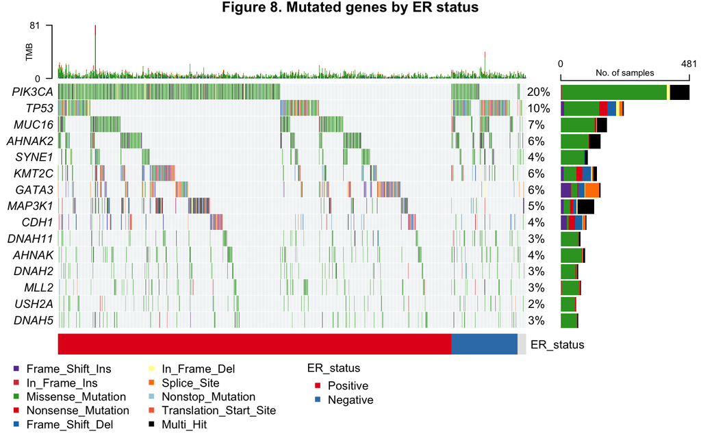

Figure 8 reveals that a large proportion of patients with a negative ER status exhibit TP53 mutations. Silwal-Pandit and colleagues have previously demonstrated that TP53 mutations are more common in aggressive subtypes, which are oftentimes ER-negative. Given this concordance with previous research, this association appears to be robust.

Integration of molecular and clinical data enabled us to identify a more precise characterization of tumor heterogeneity in this cohort than would have been possible using only one data type. As He et al. (2019) showed, the process of combining gene expression with clinical variables significantly improves breast cancer stratification.

# Methods

## Data Access Requirements

**Dataset Source:** Dataset was obtained from the subset of Molecular Taxonomy of Breast Cancer International Consortium (METABRIC) study used for teaching purposes. This study provides well-structured breast cancer cohort data with matched clinical, genomic and transcriptomic characteristics.

**Original format:** This dataset was provided in the following formats: - Clinical metadata has been provided in comma-separated values (CSV) format - Gene expression data has been provided in tab-delimited text (TXT) format - Somatic mutation data has been provided in Mutation Annotation format (MAF)

**Format used in the research:** For the purposes of the analysis, gene expression data were converted into numeric matrices as rows and samples as columns. Clinical data were retained as structured data frames and mutation data were processed using the *maftools* package for structured mutation analysis.

**Access methods:** The dataset was provided for educational purposes through VLE platform under Assignment tab in Module 3 section. All data files used for the analysis were stored in the working directory.

## Data Governance and Ethics

**Privacy considerations:** All data used for analysis in this study was anonymized and contained no personally identifiable information.

**Ethical use:** Data for this study were used for research and academic purposes only.

**License and usage:** All data provided under University of Cambridge terms for research and academic analysis.

## Dataset Structure and Metadata

The METABRIC dataset consists of:  
1. Clinical metadata, including unique patient identifiers and associated clinical variables such as ER status, PAM50 subtype classification, HER2 status, age at diagnosis and others.  
2. Gene expression matrix with genes indexed by Hugo gene symbol and expression values.  
3. Somatic mutation data provided in MAF format containing mutation annotations.

Unique patient identifiers (patient_id) were used to harmonize samples and perform the analysis.

## Analytical workflow overview

The following workflow sequence has been applied throughout this study:

1. Initial data loading and preprocessing (recoding of ER_status_ihc variable to correct misspelled category label).
2. Gene-level aggregation and expression matrix construction.
3. PAM50 subtype-stratified expression analysis.
4. Mutation burden estimation and visualization.
5. Integration of molecular and clinical features.

## Overview of statistical and analytical methods

The following research methods have been applied as part of data analysis:

# Discussion

Breast cancer is known for being a highly heterogeneous disease that should be analyzed from both clinical and molecular perspectives. This study had an objective to evaluate whether PAM50 intrinsic subtypes meaningfully stratify transcriptional, molecular and clinical heterogeneity within the METABRIC cohort. The integration of mutation, gene expression and clinical data allowed us to assess the practical significance, as well as biological coherence of PAM50 subtypes.

## Key Findings

**PAM50 subtype classification:** Gene expression analysis performed across two PAM50 molecular subtypes (Luminal A and HER2-enriched) showed that they reflect consistent differences in gene expression patterns across tumors. The results of principal component analysis demonstrated the existence of partial overlap between Luminal A and HER2-enriched tumors. Nevertheless, subtype-related expression differences observed in several key genes were in line with the known characteristics of breast cancer subtype biology. In this cohort, HER2-enriched tumors revealed an increased expression of ERBB2, while Luminal A was unexpectedly associated with a higher MKI67 expression. This finding differs from the results of previously published studies on breast cancer molecular subtypes.

**Mutational analysis and driver genes:** Based on the results of the mutation analysis, we were able to identify subtype-associated enrichment of driver genes. MAP3K1 and GATA3 mutations occurred in Luminal A tumors more frequently, while HER2-enriched tumors had a higher proportion of TP53 mutations. According to Huszno and Grzybowska (2018), TP53 mutation is known to be a negative prognostic factor in breast cancer, as tumors with this mutation have a high chance of being more aggressive. Usary et al. (2004) showed that GATA3 mutations frequently occur in ER-positive breast cancer, thereby supporting its association with luminal breast cancer subtypes. MAP3K1 mutations, as demonstrated by Ellis et al. (2012), are enriched in luminal tumors. Many PAM50 subtypes share the same mutations and hence cannot be fully defined by a single-gene change or overall mutation burden.

## Interpretation in the Broader Breast Cancer Research Context

The findings of this study are consistent with the current direction of breast cancer research that recognizes that biological features of tumors may be shared across molecular subtypes and therefore any classification should not be applied too rigidly.

From a clinical perspective, the interpretation of these results suggests that modern cancer treatment strategies should incorporate multi-modal approaches involving molecular, clinical and transcriptomic data to improve patient outcomes.

## Strenghts and Limitations

Strengths of this research include the integration of a multi-modal approach, which combines clinical, mutational and transcriptomic data. Analytical and statistical methods have been appropriately selected to support the main objective of this study.

Limitations of this research are related to the focused analysis of specific PAM50 subtypes, which makes the results not fully generalizable across the entire PAM50 spectrum.

## Further Developments and Future Directions

Future breast cancer research could be advanced with the integration of more sophisticated and modern technologies such as RNA sequencing. This will allow us to extend our analysis beyond 50 predefined genes, which are part of PAM50 classifier. The results of this study could be further validated in different cohorts, particularly among underrepresented patient populations. Finally, additional longitudinal studies could be conducted to evaluate whether subtypes change in response to targeted cancer therapies.

# Conclusion

Breast cancer has been categorized by its inherent heterogeneity and PAM50 subtypes provide us with a structured framework for stratifying tumors. To achieve its full potential in clinical practice, this model should be combined with multi-modal data.

# References

R Core Team (2025) *R: A language and environment for statistical computing*. Version 4.5.1. Vienna: R Foundation for Statistical Computing. Available at: https://WWW.R-project.org/ (Accessed: 16 February 2026).

World Health Organization (2024) *Breast cancer*. Available at: https://WWW.who.int/news-room/fact-sheets/detail/breast-cancer (Accessed: 16 February 2026).

Ultimescu, F., Hudita, A., Popa, D.E., Olinca, M., Muresean, H.A., Ceausu, M., Stanciu, D.I., Ginghina, O. and Galateanu, B. (2024) ‘Impact of molecular profiling on therapy management in breast cancer’, *Journal of Clinical Medicine*, 13(17), p.4995. doi:10.3390/jcm13174995.

Curtis, C. et al. (2012) ‘The genomic and transcriptomic architecture of 2,000 breast tumours reveals novel subgroups’, *Nature*, 486(7403), pp.346–352. doi:10.1038/nature10983.

Kim, J., Harper, A., McCormack, V., et al. (2025) ‘Global patterns and trends in breast cancer incidence and mortality across 185 countries’, *Nature Medicine*, 31, pp.1154–1162. doi:10.1038/s41591-025-03502-3.

Rakha, E.A., El-Sheikh, S., Aleskandarany, M., et al. (2022) ‘An update on the pathological classification of breast cancer’, *Histopathology*, 80(6), pp.969–989. doi:10.1111/his.14786.

Parker, J.S., Mullins, M., Cheang, M.C.U., Leung, S., Voduc, D., Vickery, T., Davies, S., Fauron, C., He, X., Hu, Z., Quackenbush, J.F., Stijleman, I.J., Palazzo, J., Marron, J.S., Nobel, A.B., Mardis, E., Nielsen, T.O., Ellis, M.J., Perou, C.M. and Bernard, P.S. (2009) ‘Supervised risk predictor of breast cancer based on intrinsic subtypes’, *Journal of Clinical Oncology*, 27(8), pp.1160–1167. doi:10.1200/JCO.2008.18.1370.

Gao, J.J. and Swain, S.M., 2018. ‘Luminal A breast cancer and molecular assays: a review’, *The Oncologist*, 23(5), pp.556–565. doi.org/10.1634/theoncologist.2017-0535.

Zhou, L., Zhang, Y., Zhang, J., Wang, H., Zhao, B., Cai, Y., Qu, Y., Li, X. and Zhang, D., 2025. ‘Clinical characteristics and therapeutic direction of HER2 low-expression breast cancer’, *Frontiers in Oncology*, 15, 1484103. doi.org/10.3389/fonc.2025.1484103.

Perou, C.M., Sørlie, T., Eisen, M.B., van de Rijn, M., Jeffrey, S.S., Rees, C.A., Pollack, J.R., Ross, D.T., Johnsen, H., Akslen, L.A., Fluge, Ø., Pergamenschikov, A., Williams, C., Zhu, S.X., Lønning, P.E., Børresen-Dale, A.L., Brown, P.O. and Botstein, D. (2000) ‘Molecular portraits of human breast tumours’, *Nature*, 406(6797), pp. 747–752. doi:10.1038/35021093.

The Cancer Genome Atlas Network (2012) ‘Comprehensive molecular portraits of human breast tumours’, *Nature*, 490(7418), pp. 61–70. https://doi.org/10.1038/nature11412.

He, Z., Zhang, J., Yuan, X., Xi, J., Liu, Z. and Zhang, Y. (2019) ‘Stratification of breast cancer by integrating gene expression data and clinical variables’, *Molecules*, 24(3), p. 631. https://doi.org/10.3390/molecules24030631.

Soliman, N.A. and Yussif, S.M. (2016) ‘Ki-67 as a prognostic marker according to breast cancer molecular subtype’, *Cancer Biology & Medicine*, 13(4), pp. 496–504. https://doi.org/10.20892/j.issn.2095-3941.2016.0066.

Prat, A. et al. (2013) ‘Phenotypic and molecular characterization of the claudin-low intrinsic subtype of breast cancer’, *Breast Cancer Research*, 15(2), p. R47. https://doi.org/10.1186/bcr3408.

Silwal-Pandit, L., Vollan, H.K.M., Chin, S.F., Rueda, O.M., McKinney, S., Osako, T., Quigley, D.A., Kristensen, V.N., Aparicio, S., Børresen-Dale, A.L., Caldas, C. and Langerød, A. (2014) ‘TP53 mutation spectrum in breast cancer is subtype specific and has distinct prognostic relevance’, *Clinical Cancer Research*, 20(13), pp. 3569–3580. https://doi.org/10.1158/1078-0432.CCR-13-2943.

Huszno, J. and Grzybowska, E. (2018) ‘TP53 mutations and SNPs as prognostic and predictive factors in patients with breast cancer’, *Oncology Letters*, 16(1), pp. 34–40. https://doi.org/10.3892/ol.2018.8627.

Usary, J., Llaca, V., Karaca, G., Presswala, S., Karaca, M., He, X., Langerød, A., Kåresen, R., Oh, D.S., Dressler, L.G., Lønning, P.E., Strausberg, R.L., Chanock, S., Børresen-Dale, A.L. and Perou, C.M. (2004) ‘Mutation of GATA3 in human breast tumors’, *Oncogene*, 23(46), pp. 7669–7678. doi:10.1038/sj.onc.1207966.

Ellis MJ, Ding L, Shen D, Luo J, Suman VJ, Wallis JW, Van Tine BA, Hoog J, Goiffon RJ, Goldstein TC, Ng S, Lin L, Crowder R, Snider J, Ballman K, Weber J, Chen K, Koboldt DC, Kandoth C, Schierding WS, McMichael JF, Miller CA, Lu C, Harris CC, McLellan MD, Wendl MC, DeSchryver K, Allred DC, Esserman L, Unzeitig G, Margenthaler J, Babiera GV, Marcom PK, Guenther JM, Leitch M, Hunt K, Olson J, Tao Y, Maher CA, Fulton LL, Fulton RS, Harrison M, Oberkfell B, Du F, Demeter R, Vickery TL, Elhammali A, Piwnica-Worms H, McDonald S, Watson M, Dooling DJ, Ota D, Chang LW, Bose R, Ley TJ, Piwnica-Worms D, Stuart JM, Wilson RK, Mardis ER. ‘Whole-genome analysis informs breast cancer response to aromatase inhibition’, *Nature*. 2012 Jun 10;486(7403):353-60. doi: 10.1038/nature11143.

## Hyperlinks

[Healthcare DataScience GitHub Repository](https://github.com/NikitaFilimonow/Healthcare-DataScience)